# Part II - Analysis of Ford GoBike System Data

## by Jonathan Akwasi Adusei

## Investigation Overview

> The investigation in this project focused on how trip duration varies depending on the day and time of trip, as well as customer type.

## Key insights

> 1. The higher ride frequencies in the morning (8th and 9th hrs) and evening (17th and 18th hrs) can be attributed to rush hours when people leave for work and return later in the evening.
> 2. Trips by customer user type last longer than trips by subscriber user type.
> 3. Weekend trips last longer than weekday trips.

## Dataset Overview

> The data comes from Ford GoBike, a bike-sharing service. It was founded in 2013 and is based in San Francisco, California. They now have around 3,000 bicycles and 270 stations in northern California. I examined data from the San Francisco Bay Area between February and March 2019 for this project. The data contained the following characteristics: member's birth and gender, User Type (Subscriber or Customer), Trip Duration (in seconds), Trip Start and End Dates, Start and End Station Names, and so on.

## Ride Distribution Over The Days of The Week

The majority of rides were taken on Thursdays and Tuesdays. Weekends have the fewest trips.

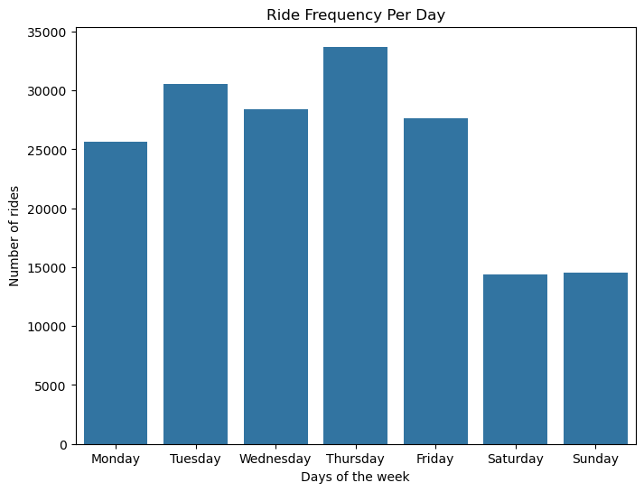

## Bike Ride Distribution by Hours

High ride frequencies largely occur at peak hours when people are going to work in the morning (8:00 and 9:00 a.m.) and when they are leaving in the evening (17:00 and 18:00 p.m.).

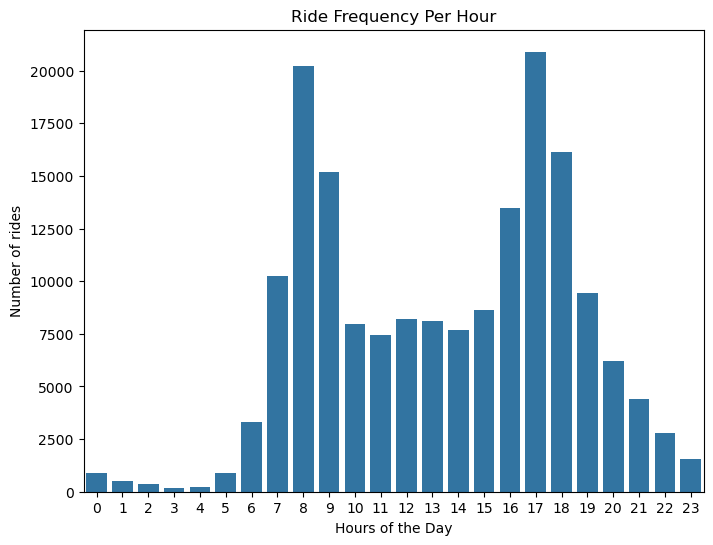

## Distribution of Rides by User Type

Over 90% of all rides are taken by subscribers.

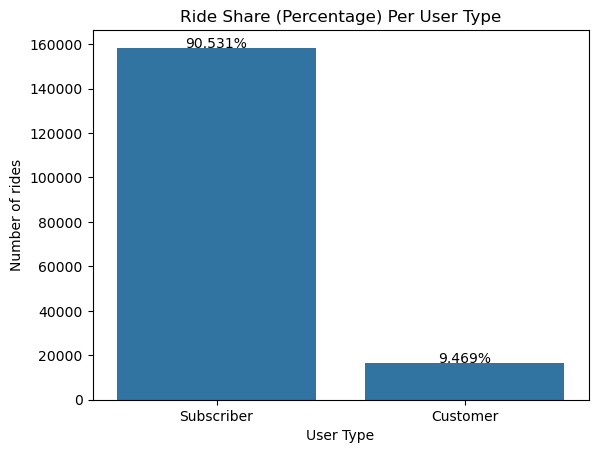

## Distribution of Trip Duration across Days and Customer Types

Trips taken by customers were longer irrespective of the day of the week, yet were longest on weekends. Subscribers on the other hand largely travel a short distance with a slight increase on weekends but not to the extent of customers.

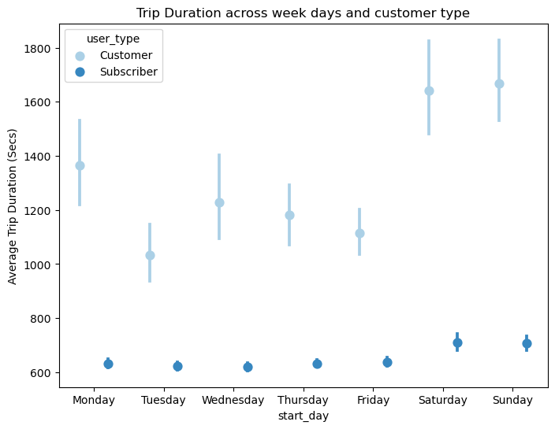